# COMPSCIX 415.2 Homework 7

Katherine Leu

July 24, 2018

```r
library(tidyverse)
library(broom)
```

## Exercise 1

### Load the train.csv dataset into R. How many observations and columns are there?

```r
houseprices <- read.csv(file="C:/Users/Katie/Documents/R/compscix-415-2-assignments/train.csv")
as_tibble(houseprices)
```

```
## # A tibble: 1,460 x 81
##       Id MSSubClass MSZoning LotFrontage LotArea Street Alley LotShape
##    <int>      <int> <fct>          <int>   <int> <fct>  <fct> <fct>
##  1     1         60 RL                65    8450 Pave   <NA>  Reg
##  2     2         20 RL                80    9600 Pave   <NA>  Reg
##  3     3         60 RL                68   11250 Pave   <NA>  IR1
##  4     4         70 RL                60    9550 Pave   <NA>  IR1
##  5     5         60 RL                84   14260 Pave   <NA>  IR1
##  6     6         50 RL                85   14115 Pave   <NA>  IR1
##  7     7         20 RL                75   10084 Pave   <NA>  Reg
##  8     8         60 RL                NA   10382 Pave   <NA>  IR1
##  9     9         50 RM                51    6120 Pave   <NA>  Reg
## 10    10        190 RL                50    7420 Pave   <NA>  Reg
## # ... with 1,450 more rows, and 73 more variables: LandContour <fct>,
## #   Utilities <fct>, LotConfig <fct>, LandSlope <fct>, Neighborhood <fct>,
## #   Condition1 <fct>, Condition2 <fct>, BldgType <fct>, HouseStyle <fct>,
## #   OverallQual <int>, OverallCond <int>, YearBuilt <int>,
## #   YearRemodAdd <int>, RoofStyle <fct>, RoofMatl <fct>,
## #   Exterior1st <fct>, Exterior2nd <fct>, MasVnrType <fct>,
## #   MasVnrArea <int>, ExterQual <fct>, ExterCond <fct>, Foundation <fct>,
## #   BsmtQual <fct>, BsmtCond <fct>, BsmtExposure <fct>,
## #   BsmtFinType1 <fct>, BsmtFinSF1 <int>, BsmtFinType2 <fct>,
## #   BsmtFinSF2 <int>, BsmtUnfSF <int>, TotalBsmtSF <int>, Heating <fct>,
## #   HeatingQC <fct>, CentralAir <fct>, Electrical <fct>, X1stFlrSF <int>,
## #   X2ndFlrSF <int>, LowQualFinSF <int>, GrLivArea <int>,
## #   BsmtFullBath <int>, BsmtHalfBath <int>, FullBath <int>,
## #   HalfBath <int>, BedroomAbvGr <int>, KitchenAbvGr <int>,
## #   KitchenQual <fct>, TotRmsAbvGrd <int>, Functional <fct>,
## #   Fireplaces <int>, FireplaceQu <fct>, GarageType <fct>,
## #   GarageYrBlt <int>, GarageFinish <fct>, GarageCars <int>,
## #   GarageArea <int>, GarageQual <fct>, GarageCond <fct>,
## #   PavedDrive <fct>, WoodDeckSF <int>, OpenPorchSF <int>,
## #   EnclosedPorch <int>, X3SsnPorch <int>, ScreenPorch <int>,
## #   PoolArea <int>, PoolQC <fct>, Fence <fct>, MiscFeature <fct>,
## #   MiscVal <int>, MoSold <int>, YrSold <int>, SaleType <fct>,
## #   SaleCondition <fct>, SalePrice <int>
```

There are 1460 observations (rows) and 81 columns.

## Exercise 2

### Visualize the distribution of `SalePrice`.

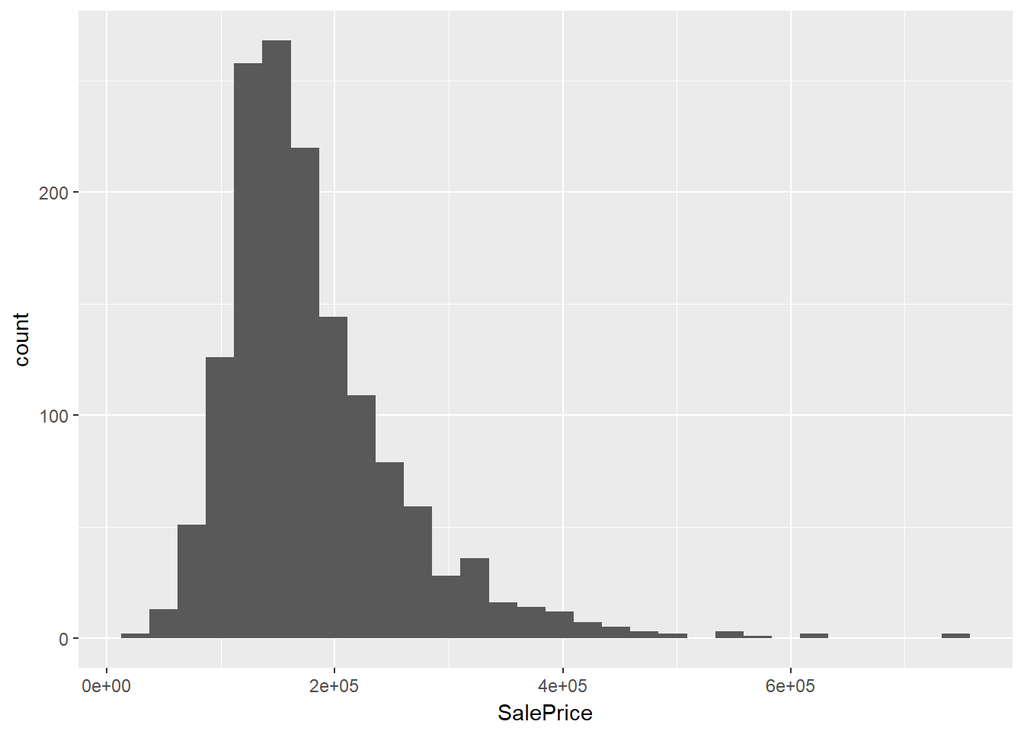

```r
houseprices %>% ggplot() +
  geom_histogram(mapping=aes(x=SalePrice))
```

### Visualize the covariation between `SalePrice` and `Neighborhood`.

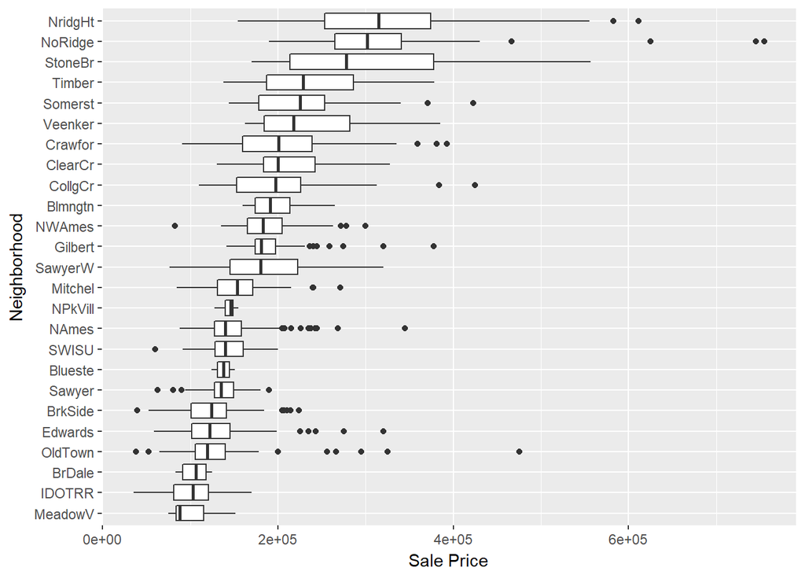

```r
houseprices %>% ggplot() +
  geom_boxplot(mapping=aes(x=reorder(Neighborhood, SalePrice, FUN=median), y=SalePrice)) +
  labs(x="Neighborhood", y="Sale Price") +
  coord_flip()
```

### Visualize the covariation between `SalePrice` and `OverallQual`.

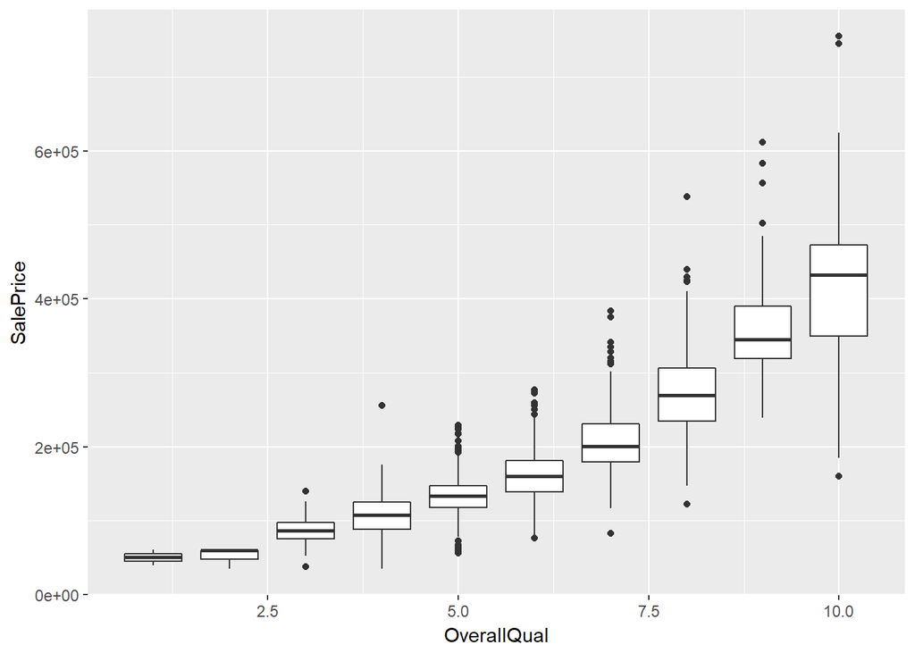

```r
houseprices %>% ggplot(mapping=aes(group=OverallQual, x=OverallQual, y=SalePrice)) +
  geom_boxplot()
```

## Exercise 3

### Our target is called `SalePrice`. First, we can fit a simple regression model consisting of only the intercept (the average of `SalePrice`). Fit the model and then use the `broom` package to take a look at the coefficient, compare the coefficient to the average value of `SalePrice`, and take a look at the R-squared.

```r
# Intercept-only model
houseprices_lm <- lm(formula= SalePrice ~ 1, data = houseprices)
tidy(houseprices_lm)
```

```
##          term estimate std.error statistic p.value
## 1 (Intercept) 180921.2  2079.105  87.01877       0
```

```r
avgSalePrice = mean(houseprices$SalePrice)
avgSalePrice
```

```
## [1] 180921.2
```

```r
glance(houseprices_lm)
```

```
##   r.squared adj.r.squared   sigma statistic p.value df    logLik      AIC
## 1         0             0 79442.5        NA      NA  1 -18544.02 37092.04
##        BIC     deviance df.residual
## 1 37102.62 9.207911e+12        1459
```

The coefficient of the intercept-only model is equal to the average of `SalePrice`, 180921.2. The R-squared value is 0, which means the model is not explaining any of the variance in the data.

## Exercise 4

### Now fit a linear regression model using `GrLivArea`, `OverallQual`, and `Neighborhood` as the features. Don’t forget to look at `data_description.txt` to understand what these variables mean. Ask yourself these questions before fitting the model:

### What kind of relationship will these features have with our target?

### Can the relationship be estimated linearly?

### Are these good features, given the problem we are trying to solve?

### After fitting the model, output the coefficients and the R-squared using the broom package.

```r
houseprices_lm2 <- lm(formula= SalePrice ~ GrLivArea + OverallQual + Neighborhood, data = houseprices)
tidy(houseprices_lm2)
```

```
##                   term    estimate    std.error   statistic      p.value
## 1          (Intercept) -34829.2399 11541.232315 -3.01780945 2.591005e-03
## 2            GrLivArea     55.5645     2.498787 22.23658695 2.375376e-94
## 3          OverallQual  20951.4249  1162.273747 18.02623948 1.238994e-65
## 4  NeighborhoodBlueste -30752.8759 27697.270091 -1.11032155 2.670468e-01
## 5   NeighborhoodBrDale -43358.8812 12978.523255 -3.34081778 8.568095e-04
## 6  NeighborhoodBrkSide -13025.4529 10450.444653 -1.24640179 2.128206e-01
## 7  NeighborhoodClearCr  24575.6351 11569.625542  2.12415129 3.382834e-02
## 8  NeighborhoodCollgCr  11414.3095  9496.581581  1.20193876 2.295858e-01
## 9  NeighborhoodCrawfor  14444.2502 10502.214763  1.37535278 1.692371e-01
## 10 NeighborhoodEdwards -17842.9513  9985.733698 -1.78684430 7.417398e-02
## 11 NeighborhoodGilbert   -892.8796  9954.350137 -0.08969743 9.285402e-01
## 12  NeighborhoodIDOTRR -28178.9866 11135.583978 -2.53053514 1.149517e-02
## 13 NeighborhoodMeadowV -19099.0203 12999.351487 -1.46922870 1.419903e-01
## 14 NeighborhoodMitchel   2030.6121 10555.017277  0.19238359 8.474690e-01
## 15   NeighborhoodNAmes  -4430.0994  9517.290569 -0.46547906 6.416592e-01
## 16 NeighborhoodNoRidge  64642.9895 10939.818250  5.90896375 4.294924e-09
## 17 NeighborhoodNPkVill -17807.1837 15304.007123 -1.16356347 2.447947e-01
## 18 NeighborhoodNridgHt  71587.8398  9994.775058  7.16252635 1.262091e-12
## 19  NeighborhoodNWAmes  -4720.6584 10079.514642 -0.46834183 6.396114e-01
## 20 NeighborhoodOldTown -32080.8775  9863.373223 -3.25252596 1.170466e-03
## 21  NeighborhoodSawyer  -1219.3805 10211.495047 -0.11941254 9.049653e-01
## 22 NeighborhoodSawyerW    303.0986 10264.231736  0.02952960 9.764463e-01
## 23 NeighborhoodSomerst  17766.9637  9829.881193  1.80744440 7.090264e-02
## 24 NeighborhoodStoneBr  69954.4718 11689.508047  5.98438117 2.740136e-09
## 25   NeighborhoodSWISU -36640.1517 11923.592410 -3.07291213 2.159781e-03
## 26  NeighborhoodTimber  29905.8114 10829.232809  2.76158172 5.825641e-03
## 27 NeighborhoodVeenker  47106.8929 14337.857486  3.28549039 1.042655e-03
```

```r
glance(houseprices_lm2)
```

```
##   r.squared adj.r.squared    sigma statistic p.value df    logLik      AIC
## 1 0.7868484      0.782981 37008.52  203.4583       0 27 -17415.62 34887.25
##        BIC     deviance df.residual
## 1 35035.26 1.962681e+12        1433
```

### Answer these questions:

### How would you interpret the coefficients on `GrLivArea` and `OverallQual`?

For `GrLivArea`, the coefficient is interpreted as: with a unit increase in the aboveground square footage of living space, holding house quality and neighborhood constant, the sale price will increase on average by about $56.

For `OverallQual`, the coefficient is interpreted as: with a unit increase in the quality rating of the house’s finish and material, holding square footage and neighborhood constant, the sale price will increase on average by about $20,951.

### How would you interpret the coefficient on `NeighborhoodBrkSide`?

Compared to a house in the neighborhood of Bloomington Heights, a house in the neighborhood of Brookside, holding square footage and house quality constant, will cost about $13,025 less, on average.

### Are the features significant?

The features `GrLivArea` and `OverallQual` are both very statistically significant, with p-values of very close to 0. Certain of the values of `Neighborhood` have p-values that are significant at the 0.05 level, though not all are.

### Are the features practically significant?

The coefficients for `OverallQual` and `Neighborhood` seem to be practically significant, since in dollar terms $20,951 (the coefficient for `OverallQual`) is quite a bit of money, and the dollar value of the coefficients on most of the values of `Neighborhood` are similarly large. However, the coefficient for `GrLivArea` is only $55, which is a pretty inconsequential value in the context of house prices.

### Is the model a good fit?

The model’s R-squared value is 0.79 (0.78 for adjusted R-squared), which is pretty high: the model explains 79 percent of the variance in house prices. Thus, the model fits pretty well.

## Exercise 5 (OPTIONAL - won’t be graded)

### Feel free to play around with linear regression. Add some other features and see how the model results change.

```r
houseprices_lm3 <- lm(formula= SalePrice ~ GrLivArea + OverallQual + Neighborhood + Condition1, data = houseprices)
tidy(houseprices_lm3)
```

```
##                   term     estimate    std.error   statistic      p.value
## 1          (Intercept) -48003.36712 13052.740143 -3.67764673 2.441478e-04
## 2            GrLivArea     56.65959     2.526909 22.42248845 1.280893e-95
## 3          OverallQual  20622.08447  1166.105632 17.68457667 1.991333e-63
## 4  NeighborhoodBlueste -31101.52401 27598.787159 -1.12691633 2.599676e-01
## 5   NeighborhoodBrDale -43537.42878 12933.844787 -3.36616292 7.825025e-04
## 6  NeighborhoodBrkSide -12047.77191 10478.507258 -1.14976032 2.504355e-01
## 7  NeighborhoodClearCr  25228.60703 11531.349350  2.18782783 2.884411e-02
## 8  NeighborhoodCollgCr  11283.67091  9463.661208  1.19231560 2.333360e-01
## 9  NeighborhoodCrawfor  14001.97366 10468.041246  1.33759252 1.812427e-01
## 10 NeighborhoodEdwards -16560.52425  9962.266791 -1.66232491 9.666757e-02
## 11 NeighborhoodGilbert  -1435.03001  9953.235702 -0.14417724 8.853809e-01
## 12  NeighborhoodIDOTRR -27139.79776 11125.226988 -2.43948261 1.482959e-02
## 13 NeighborhoodMeadowV -19586.08891 12957.977429 -1.51150818 1.308807e-01
## 14 NeighborhoodMitchel   2220.38896 10519.906913  0.21106546 8.328664e-01
```

[output cut: 21 more lines]

```r
glance(houseprices_lm3)
```

```
##   r.squared adj.r.squared    sigma statistic p.value df    logLik      AIC
## 1 0.7895498     0.7845286 36876.34  157.2412       0 35 -17406.31 34884.62
##        BIC     deviance df.residual
## 1 35074.93 1.937806e+12        1425
```

```r
houseprices_lm4 <- lm(formula= SalePrice ~ GrLivArea + OverallQual + Neighborhood + HouseStyle, data = houseprices)
tidy(houseprices_lm4)
```

```
##                   term     estimate    std.error   statistic       p.value
## 1          (Intercept) -75088.64165 12003.126602 -6.25575687  5.218918e-10
## 2            GrLivArea     72.04715     2.900198 24.84214526 1.697876e-113
## 3          OverallQual  19825.41915  1136.248616 17.44813492  6.064401e-62
## 4  NeighborhoodBlueste  -3671.12683 26787.979496 -0.13704381  8.910155e-01
## 5   NeighborhoodBrDale -12519.67867 12856.177360 -0.97382591  3.303081e-01
## 6  NeighborhoodBrkSide   4173.62067 10307.192142  0.40492315  6.855947e-01
## 7  NeighborhoodClearCr  31241.27187 11184.359022  2.79330016  5.287079e-03
## 8  NeighborhoodCollgCr  19742.06700  9182.650660  2.14993118  3.172841e-02
## 9  NeighborhoodCrawfor  24974.94125 10165.011009  2.45695172  1.413055e-02
## 10 NeighborhoodEdwards  -9410.69859  9678.891399 -0.97229096  3.310707e-01
## 11 NeighborhoodGilbert  16985.04717  9768.010961  1.73884399  8.227802e-02
## 12  NeighborhoodIDOTRR  -9588.58257 10927.526341 -0.87747055  3.803789e-01
## 13 NeighborhoodMeadowV  -5692.63434 12842.887693 -0.44325190  6.576508e-01
## 14 NeighborhoodMitchel   6013.50379 10211.686680  0.58888448  5.560320e-01
```

[output cut: 20 more lines]

```r
glance(houseprices_lm4)
```

```
##   r.squared adj.r.squared    sigma statistic p.value df    logLik      AIC
## 1 0.8036649     0.7991213 35605.72  176.8816       0 34 -17355.63 34781.26
##        BIC     deviance df.residual
## 1 34966.28 1.807836e+12        1426
```

```r
houseprices_lm5 <- lm(formula= SalePrice ~ GrLivArea + OverallQual + Neighborhood + YrSold, data = houseprices)
tidy(houseprices_lm5)
```

```
##                   term      estimate    std.error   statistic      p.value
## 1          (Intercept) -194043.45569 1.479444e+06 -0.13115971 8.956674e-01
## 2            GrLivArea      55.57305 2.500911e+00 22.22112066 3.130904e-94
## 3          OverallQual   20951.13972 1.162678e+03 18.01972948 1.377216e-65
## 4  NeighborhoodBlueste  -30834.54679 2.771722e+04 -1.11246904 2.661233e-01
## 5   NeighborhoodBrDale  -43374.07404 1.298377e+04 -3.34063814 8.573748e-04
## 6  NeighborhoodBrkSide  -13040.14255 1.045494e+04 -1.24727071 2.125022e-01
## 7  NeighborhoodClearCr   24547.19887 1.157663e+04  2.12040910 3.414309e-02
## 8  NeighborhoodCollgCr   11387.05422 9.503234e+03  1.19822945 2.310260e-01
## 9  NeighborhoodCrawfor   14439.32928 1.050594e+04  1.37439695 1.695335e-01
## 10 NeighborhoodEdwards  -17880.02488 9.995117e+03 -1.78887592 7.384611e-02
## 11 NeighborhoodGilbert    -901.73022 9.958125e+03 -0.09055221 9.278611e-01
## 12  NeighborhoodIDOTRR  -28199.92971 1.114113e+04 -2.53115615 1.147501e-02
## 13 NeighborhoodMeadowV  -19143.28813 1.301034e+04 -1.47139020 1.414053e-01
## 14 NeighborhoodMitchel    2008.73982 1.056062e+04  0.19021049 8.491711e-01
## 15   NeighborhoodNAmes   -4461.02326 9.524910e+03 -0.46835334 6.396032e-01
## 16 NeighborhoodNoRidge   64605.51811 1.094913e+04  5.90051586 4.515913e-09
## 17 NeighborhoodNPkVill  -17900.87973 1.533402e+04 -1.16739617 2.432448e-01
## 18 NeighborhoodNridgHt   71556.41089 1.000249e+04  7.15386133 1.341914e-12
## 19  NeighborhoodNWAmes   -4751.32572 1.008702e+04 -0.47103371 6.376884e-01
## 20 NeighborhoodOldTown  -32106.97151 9.869755e+03 -3.25306663 1.168277e-03
## 21  NeighborhoodSawyer   -1251.58623 1.021940e+04 -0.12247159 9.025427e-01
## 22 NeighborhoodSawyerW     241.96715 1.028347e+04  0.02352971 9.812310e-01
## 23 NeighborhoodSomerst   17743.86947 9.835614e+03  1.80404285 7.143465e-02
## 24 NeighborhoodStoneBr   69915.25490 1.169922e+04  5.97606225 2.880583e-09
## 25   NeighborhoodSWISU  -36698.51236 1.194003e+04 -3.07357019 2.155083e-03
## 26  NeighborhoodTimber   29875.68200 1.083659e+04  2.75692740 5.908812e-03
## 27 NeighborhoodVeenker   47143.13040 1.434676e+04  3.28597825 1.040882e-03
## 28              YrSold      79.30580 7.368998e+02  0.10762088 9.143115e-01
```

```r
glance(houseprices_lm5)
```

```
##   r.squared adj.r.squared    sigma statistic p.value df    logLik      AIC
## 1 0.7868501     0.7828312 37021.29  195.7881       0 28 -17415.62 34889.23
##        BIC     deviance df.residual
## 1 35042.53 1.962665e+12        1432
```

## Exercise 6

### One downside of the linear model is that it is sensitive to unusual values because the distance incorporates a squared term. Fit a linear model to the simulated data below (use y as the target and x as the feature), and look at the resulting coefficients and R-squared. Rerun it about 5-6 times to generate different simulated datasets. What do you notice about the model’s coefficient on x and the R-squared values?

```r
sim1a <- tibble(
  x = rep(1:10, each = 3),
  y = x * 1.5 + 6 + rt(length(x), df = 2)
)
sim1a_lm <- lm(y ~ x, data=sim1a)
tidy(sim1a_lm)
```

```
##          term estimate std.error statistic      p.value
## 1 (Intercept) 5.673778 0.8258668  6.870089 1.822699e-07
## 2           x 1.561397 0.1331005 11.730964 2.538623e-12
```

```r
glance(sim1a_lm)
```

```
##   r.squared adj.r.squared    sigma statistic      p.value df    logLik
## 1 0.8309337     0.8248956 2.093954  137.6155 2.538623e-12  2 -63.70489
##        AIC      BIC deviance df.residual
## 1 133.4098 137.6134 122.7701          28
```

```r
sim1b <- tibble(
  x = rep(1:10, each = 3),
  y = x * 1.5 + 6 + rt(length(x), df = 2)
)
sim1b_lm <- lm(y ~ x, data=sim1b)
tidy(sim1b_lm)
```

```
##          term estimate std.error statistic      p.value
## 1 (Intercept) 6.812761 0.6210040  10.97056 1.198534e-11
## 2           x 1.339439 0.1000838  13.38316 1.089465e-13
```

```r
glance(sim1b_lm)
```

```
##   r.squared adj.r.squared    sigma statistic      p.value df    logLik
## 1 0.8648055     0.8599772 1.574532  179.1091 1.089465e-13  2 -55.15201
##       AIC      BIC deviance df.residual
## 1 116.304 120.5076 69.41626          28
```

```r
sim1c <- tibble(
  x = rep(1:10, each = 3),
  y = x * 1.5 + 6 + rt(length(x), df = 2)
)
sim1c_lm <- lm(y ~ x, data=sim1c)
tidy(sim1c_lm)
```

```
##          term estimate  std.error statistic      p.value
## 1 (Intercept) 5.767881 0.50819557  11.34973 5.480688e-12
## 2           x 1.641814 0.08190313  20.04580 3.820412e-18
```

```r
glance(sim1c_lm)
```

```
##   r.squared adj.r.squared    sigma statistic      p.value df    logLik
## 1 0.9348586     0.9325321 1.288511   401.834 3.820412e-18  2 -49.13788
##        AIC      BIC deviance df.residual
## 1 104.2758 108.4794 46.48729          28
```

```r
sim1d <- tibble(
  x = rep(1:10, each = 3),
  y = x * 1.5 + 6 + rt(length(x), df = 2)
)
sim1d_lm <- lm(y ~ x, data=sim1d)
tidy(sim1d_lm)
```

```
##          term estimate std.error statistic      p.value
## 1 (Intercept) 6.688569 1.0765103  6.213196 1.033186e-06
## 2           x 1.349578 0.1734953  7.778756 1.790517e-08
```

```r
glance(sim1d_lm)
```

```
##   r.squared adj.r.squared    sigma statistic      p.value df    logLik
## 1 0.6836482     0.6723499 2.729452  60.50905 1.790517e-08  2 -71.65628
##        AIC      BIC deviance df.residual
## 1 149.3126 153.5162 208.5974          28
```

```r
sim1e <- tibble(
  x = rep(1:10, each = 3),
  y = x * 1.5 + 6 + rt(length(x), df = 2)
)
sim1e_lm <- lm(y ~ x, data=sim1e)
tidy(sim1e_lm)
```

```
##          term estimate  std.error statistic      p.value
## 1 (Intercept) 6.096695 0.60097046  10.14475 7.001582e-11
## 2           x 1.414985 0.09685516  14.60929 1.260299e-14
```

```r
glance(sim1e_lm)
```

```
##   r.squared adj.r.squared    sigma statistic      p.value df    logLik
## 1  0.884025      0.879883 1.523738  213.4313 1.260299e-14  2 -54.16826
##        AIC      BIC deviance df.residual
## 1 114.3365 118.5401 65.00979          28
```

```r
sim1f <- tibble(
  x = rep(1:10, each = 3),
  y = x * 1.5 + 6 + rt(length(x), df = 2)
)
sim1f_lm <- lm(y ~ x, data=sim1f)
tidy(sim1f_lm)
```

```
##          term estimate std.error statistic      p.value
## 1 (Intercept) 8.291333 1.1211365  7.395472 4.707216e-08
## 2           x 1.201238 0.1806875  6.648151 3.259519e-07
```

```r
glance(sim1f_lm)
```

```
##   r.squared adj.r.squared  sigma statistic      p.value df    logLik
## 1 0.6121772     0.5983264 2.8426  44.19792 3.259519e-07  2 -72.87483
##        AIC      BIC deviance df.residual
## 1 151.7497 155.9533 226.2505          28
```

Across the above iterations of models of the simulated data, the coefficient on `x` doesn’t appear to change very much, staying between 1 and 2, but the R-squared values vary quite a bit.